# Project: The Movie Database (TMDb) Analysis

## Introduction

In this project we will be analysing The Movie Database (TMDb) which contains information of over 10,000 movies including budget, revenue, cast, title, release year etc. And we'll be focus on the parameters that contributes towards the success of a movie.

### Questions that can be analysed from this data set:

1. What are top 10 most and least profitable movies?
2. What are top 10 most and least expensive movies of all time?
3. What are top 10 most and least popular movies of all time?
4. What is average runtime distribution of the movies?
5. On which year the movies released was the highest?
6. Is the average runtime of movies consistent throughout the years?
7. How is popularity related to profit?
8. How is budget related to profit?
9. Which month has most movie releases?
10. What is the correlation between each parameters?
11. What are the most frequent genres, actor and director?
12. Which is the most profitable genre, actor and director?
13. What are most profitable production companies?
14. What are some parameters that are related to movies with high revenue?

```python
# importing all the important libraries
import numpy as np
import pandas as pd
import matplotlib.pyplot as plt
import seaborn as sns

# to view visuals inside the notebook
%matplotlib inline
```

## Data Wrangling

> In this step, we will load the data and then we can proceed to exploring the data and getting rid of the columns/rows that are not needed. This will help us analyse the data easily and efficiently.

```python
# reading csv file and viewing the first few rows
df=pd.read_csv('tmdb-movies.csv')
df.head()
```

|  | id | imdb_id | popularity | budget | revenue | original_title | cast | homepage | director | tagline | ... | overview | runtime | genres | production_companies | release_date | vote_count | vote_average | release_year | budget_adj | revenue_adj |
| --- | --- | --- | --- | --- | --- | --- | --- | --- | --- | --- | --- | --- | --- | --- | --- | --- | --- | --- | --- | --- | --- |
| 0 | 135397 | tt0369610 | 32.985763 | 150000000 | 1513528810 | Jurassic World | Chris Pratt\|Bryce Dallas Howard\|Irrfan Khan\|Vi... | http://www.jurassicworld.com/ | Colin Trevorrow | The park is open. | ... | Twenty-two years after the events of Jurassic ... | 124 | Action\|Adventure\|Science Fiction\|Thriller | Universal Studios\|Amblin Entertainment\|Legenda... | 6/9/2015 | 5562 | 6.5 | 2015 | 137999939.3 | 1.392446e+09 |
| 1 | 76341 | tt1392190 | 28.419936 | 150000000 | 378436354 | Mad Max: Fury Road | Tom Hardy\|Charlize Theron\|Hugh Keays-Byrne\|Nic... | http://www.madmaxmovie.com/ | George Miller | What a Lovely Day. | ... | An apocalyptic story set in the furthest reach... | 120 | Action\|Adventure\|Science Fiction\|Thriller | Village Roadshow Pictures\|Kennedy Miller Produ... | 5/13/2015 | 6185 | 7.1 | 2015 | 137999939.3 | 3.481613e+08 |
| 2 | 262500 | tt2908446 | 13.112507 | 110000000 | 295238201 | Insurgent | Shailene Woodley\|Theo James\|Kate Winslet\|Ansel... | http://www.thedivergentseries.movie/#insurgent | Robert Schwentke | One Choice Can Destroy You | ... | Beatrice Prior must confront her inner demons ... | 119 | Adventure\|Science Fiction\|Thriller | Summit Entertainment\|Mandeville Films\|Red Wago... | 3/18/2015 | 2480 | 6.3 | 2015 | 101199955.5 | 2.716190e+08 |
| 3 | 140607 | tt2488496 | 11.173104 | 200000000 | 2068178225 | Star Wars: The Force Awakens | Harrison Ford\|Mark Hamill\|Carrie Fisher\|Adam D... | http://www.starwars.com/films/star-wars-episod... | J.J. Abrams | Every generation has a story. | ... | Thirty years after defeating the Galactic Empi... | 136 | Action\|Adventure\|Science Fiction\|Fantasy | Lucasfilm\|Truenorth Productions\|Bad Robot | 12/15/2015 | 5292 | 7.5 | 2015 | 183999919.0 | 1.902723e+09 |
| 4 | 168259 | tt2820852 | 9.335014 | 190000000 | 1506249360 | Furious 7 | Vin Diesel\|Paul Walker\|Jason Statham\|Michelle ... | http://www.furious7.com/ | James Wan | Vengeance Hits Home | ... | Deckard Shaw seeks revenge against Dominic Tor... | 137 | Action\|Crime\|Thriller | Universal Pictures\|Original Film\|Media Rights ... | 4/1/2015 | 2947 | 7.3 | 2015 | 174799923.1 | 1.385749e+09 |

5 rows × 21 columns

```python
# information about the datatypes and missing values
df.info()
```

```
<class 'pandas.core.frame.DataFrame'>
RangeIndex: 10866 entries, 0 to 10865
Data columns (total 21 columns):
id                      10866 non-null int64
imdb_id                 10856 non-null object
popularity              10866 non-null float64
budget                  10866 non-null int64
revenue                 10866 non-null int64
original_title          10866 non-null object
cast                    10790 non-null object
homepage                2936 non-null object
director                10822 non-null object
tagline                 8042 non-null object
keywords                9373 non-null object
overview                10862 non-null object
runtime                 10866 non-null int64
genres                  10843 non-null object
production_companies    9836 non-null object
release_date            10866 non-null object
vote_count              10866 non-null int64
vote_average            10866 non-null float64
release_year            10866 non-null int64
budget_adj              10866 non-null float64
revenue_adj             10866 non-null float64
dtypes: float64(4), int64(6), object(11)
memory usage: 1.7+ MB
```

```python
# total no. of rows and columns in the dataframe
df.shape
```

```
(10866, 21)
```

### Data Cleaning

#### 1. Firstly, we will delete all the duplicate rows if there are any.

```python
# To drop duplicate rows if any
df.drop_duplicates(inplace=True)
df.shape
```

```
(10865, 21)
```

#### 2. Secondly, we will drop all the columns that we won't be needing for our analysis which are id, imdb_id, budget_adj, revenue_adj, homepage, tagline, keywords and overview.

```python
# creating a list of columns that we won't be needing in this analysis
col_drop=['id','imdb_id','homepage','tagline','keywords','overview','budget_adj','revenue_adj']

# dropping the columns
df.drop(col_drop,axis=1,inplace=True)

# checking if the changes had take place
df.head()
```

|  | popularity | budget | revenue | original_title | cast | director | runtime | genres | production_companies | release_date | vote_count | vote_average | release_year |
| --- | --- | --- | --- | --- | --- | --- | --- | --- | --- | --- | --- | --- | --- |
| 0 | 32.985763 | 150000000 | 1513528810 | Jurassic World | Chris Pratt\|Bryce Dallas Howard\|Irrfan Khan\|Vi... | Colin Trevorrow | 124 | Action\|Adventure\|Science Fiction\|Thriller | Universal Studios\|Amblin Entertainment\|Legenda... | 6/9/2015 | 5562 | 6.5 | 2015 |
| 1 | 28.419936 | 150000000 | 378436354 | Mad Max: Fury Road | Tom Hardy\|Charlize Theron\|Hugh Keays-Byrne\|Nic... | George Miller | 120 | Action\|Adventure\|Science Fiction\|Thriller | Village Roadshow Pictures\|Kennedy Miller Produ... | 5/13/2015 | 6185 | 7.1 | 2015 |
| 2 | 13.112507 | 110000000 | 295238201 | Insurgent | Shailene Woodley\|Theo James\|Kate Winslet\|Ansel... | Robert Schwentke | 119 | Adventure\|Science Fiction\|Thriller | Summit Entertainment\|Mandeville Films\|Red Wago... | 3/18/2015 | 2480 | 6.3 | 2015 |
| 3 | 11.173104 | 200000000 | 2068178225 | Star Wars: The Force Awakens | Harrison Ford\|Mark Hamill\|Carrie Fisher\|Adam D... | J.J. Abrams | 136 | Action\|Adventure\|Science Fiction\|Fantasy | Lucasfilm\|Truenorth Productions\|Bad Robot | 12/15/2015 | 5292 | 7.5 | 2015 |
| 4 | 9.335014 | 190000000 | 1506249360 | Furious 7 | Vin Diesel\|Paul Walker\|Jason Statham\|Michelle ... | James Wan | 137 | Action\|Crime\|Thriller | Universal Pictures\|Original Film\|Media Rights ... | 4/1/2015 | 2947 | 7.3 | 2015 |

#### 3. Then, we will change the datatype of the column release_date from string to datetime.

```python
# changing datatype from string to datatime
df['release_date'] = pd.to_datetime(df['release_date'])

# checking the changed datatype
df.info()
```

```
<class 'pandas.core.frame.DataFrame'>
Int64Index: 10865 entries, 0 to 10865
Data columns (total 13 columns):
popularity              10865 non-null float64
budget                  10865 non-null int64
revenue                 10865 non-null int64
original_title          10865 non-null object
cast                    10789 non-null object
director                10821 non-null object
runtime                 10865 non-null int64
genres                  10842 non-null object
production_companies    9835 non-null object
release_date            10865 non-null datetime64[ns]
vote_count              10865 non-null int64
vote_average            10865 non-null float64
release_year            10865 non-null int64
dtypes: datetime64[ns](1), float64(2), int64(5), object(5)
memory usage: 1.2+ MB
```

#### 4. Also there are some rows where budget column, revenue column or runtime column has a value of 0. We will be convertng these 0 values to NaN and dropping them.

```python
# creating a list of columns that contains some values of 0
col_zero = ['budget', 'revenue', 'runtime']

# Replacing all the 0 values with NaN
df[col_zero] = df[col_zero].replace(0, np.NAN)

# dropping all the rows that contains null value
df.dropna(subset = col_zero, inplace = True)

# checking the dataset for the null values
df.info()
```

```
<class 'pandas.core.frame.DataFrame'>
Int64Index: 3854 entries, 0 to 10848
Data columns (total 13 columns):
popularity              3854 non-null float64
budget                  3854 non-null float64
revenue                 3854 non-null float64
original_title          3854 non-null object
cast                    3850 non-null object
director                3853 non-null object
runtime                 3854 non-null float64
genres                  3854 non-null object
production_companies    3808 non-null object
release_date            3854 non-null datetime64[ns]
vote_count              3854 non-null int64
vote_average            3854 non-null float64
release_year            3854 non-null int64
dtypes: datetime64[ns](1), float64(5), int64(2), object(5)
memory usage: 421.5+ KB
```

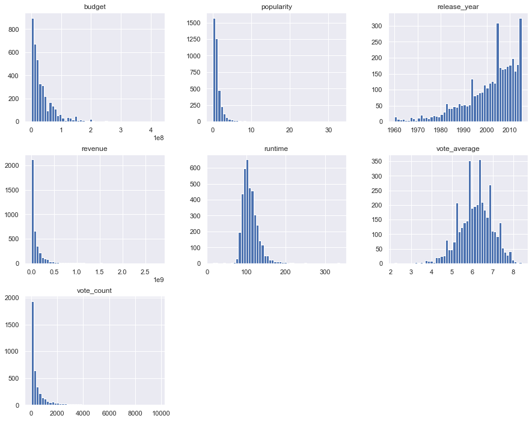

```python
# Preview overall distribution of data from each properties
df.hist(figsize = (15,12), bins=50);
```

## Exploratory Data Analysis

> Firslty we will create another column named profit which will contain the amount of profit made by each movie.

```python
# creating profit column by subtracting budget from revenue of each movie
df['profit'] = df['revenue']-df['budget']

# checking the first few rows for the changes made
df.head()
```

|  | popularity | budget | revenue | original_title | cast | director | runtime | genres | production_companies | release_date | vote_count | vote_average | release_year | profit |
| --- | --- | --- | --- | --- | --- | --- | --- | --- | --- | --- | --- | --- | --- | --- |
| 0 | 32.985763 | 150000000.0 | 1.513529e+09 | Jurassic World | Chris Pratt\|Bryce Dallas Howard\|Irrfan Khan\|Vi... | Colin Trevorrow | 124.0 | Action\|Adventure\|Science Fiction\|Thriller | Universal Studios\|Amblin Entertainment\|Legenda... | 2015-06-09 | 5562 | 6.5 | 2015 | 1.363529e+09 |
| 1 | 28.419936 | 150000000.0 | 3.784364e+08 | Mad Max: Fury Road | Tom Hardy\|Charlize Theron\|Hugh Keays-Byrne\|Nic... | George Miller | 120.0 | Action\|Adventure\|Science Fiction\|Thriller | Village Roadshow Pictures\|Kennedy Miller Produ... | 2015-05-13 | 6185 | 7.1 | 2015 | 2.284364e+08 |
| 2 | 13.112507 | 110000000.0 | 2.952382e+08 | Insurgent | Shailene Woodley\|Theo James\|Kate Winslet\|Ansel... | Robert Schwentke | 119.0 | Adventure\|Science Fiction\|Thriller | Summit Entertainment\|Mandeville Films\|Red Wago... | 2015-03-18 | 2480 | 6.3 | 2015 | 1.852382e+08 |
| 3 | 11.173104 | 200000000.0 | 2.068178e+09 | Star Wars: The Force Awakens | Harrison Ford\|Mark Hamill\|Carrie Fisher\|Adam D... | J.J. Abrams | 136.0 | Action\|Adventure\|Science Fiction\|Fantasy | Lucasfilm\|Truenorth Productions\|Bad Robot | 2015-12-15 | 5292 | 7.5 | 2015 | 1.868178e+09 |
| 4 | 9.335014 | 190000000.0 | 1.506249e+09 | Furious 7 | Vin Diesel\|Paul Walker\|Jason Statham\|Michelle ... | James Wan | 137.0 | Action\|Crime\|Thriller | Universal Pictures\|Original Film\|Media Rights ... | 2015-04-01 | 2947 | 7.3 | 2015 | 1.316249e+09 |

### Question 1. What are top 10 most and least profitable movies?

> Firstly, lets checkout the top 10 most profitable movies.

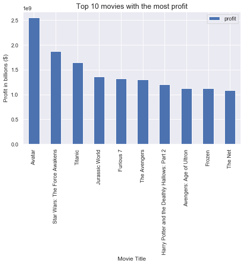

```python
# sorting the data in descending order according to profit and plotting a bar graph showing top 10 movies
most_profit=df.sort_values(['profit'],ascending=False)[:10][['original_title','profit']]
most_profit.set_index('original_title',inplace=True)
most_profit.plot(kind ='bar',figsize=(8,5))

#setup the labels of the plot
plt.title('Top 10 movies with the most profit',fontsize=15);
plt.ylabel('Profit in billions ($)',fontsize=12);
plt.xlabel('Movie Title',fontsize=12);
sns.set_style('darkgrid')
```

> Now lets find out the least 10 profitable movies.

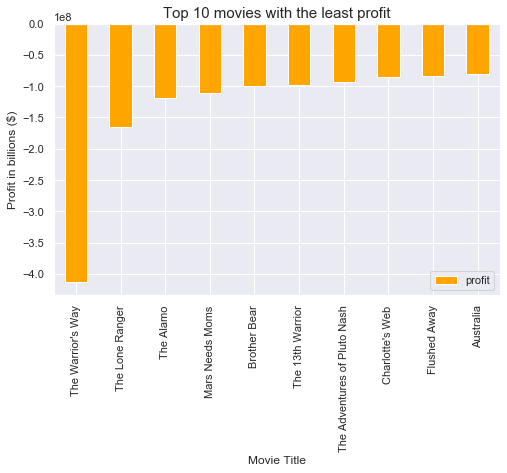

```python
# sorting the data in ascending order according to profit and plotting a bar graph showing top 10 movies
least_profit=df.sort_values(['profit'],ascending=True)[:10][['original_title','profit']]
least_profit.set_index('original_title',inplace=True)
least_profit.plot(kind ='bar',figsize=(8,5),color='orange')

#setup the labels of the plot
plt.title('Top 10 movies with the least profit',fontsize=15);
plt.ylabel('Profit in billions ($)',fontsize=12);
plt.xlabel('Movie Title',fontsize=12);
sns.set_style('darkgrid')
```

#### It is observed that Avatar is the most profitable movie and The Warrior's Way is the least profitable movie.

### Question 2. What are top 10 most and least expensive movies of all time?

> Firstly, lets checkout the most expensive ones.

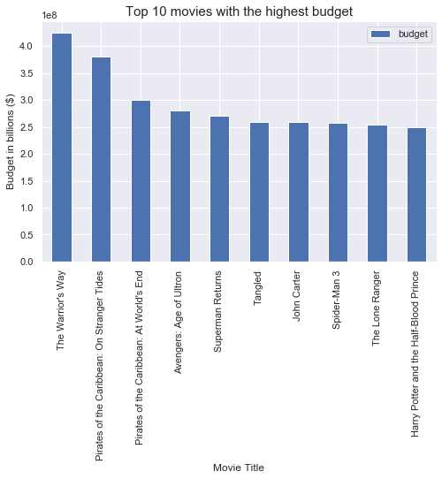

```python
# sorting the data in descending order according to the budget and plotting a bar graph showing top 10 expensive movies
sort_budget=df.sort_values(['budget'],ascending=False)[:10][['original_title','budget']]
sort_budget.set_index('original_title',inplace=True)
sort_budget.plot(kind ='bar',figsize=(8,5))

#setup the labels of the plot
plt.title('Top 10 movies with the highest budget',fontsize=15);
plt.ylabel('Budget in billions ($)',fontsize=12);
plt.xlabel('Movie Title',fontsize=12);
sns.set_style('darkgrid')
```

> Now, lets checkout the most cheapest ones.

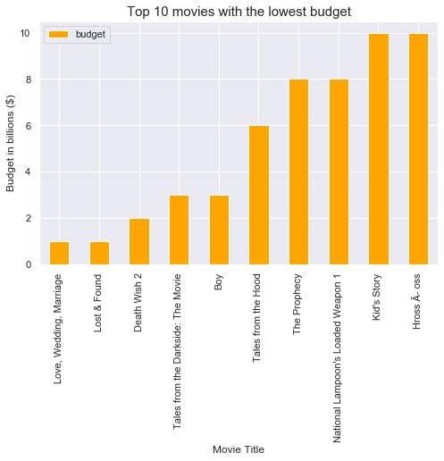

```python
# sorting the data in ascending order according to the budget and plotting a bar graph showing top 10 cheapest movies
least_budget=df.sort_values(['budget'],ascending=True)[:10][['original_title','budget']]
least_budget.set_index('original_title',inplace=True)
least_budget.plot(kind ='bar',figsize=(8,5),color='orange')

#setup the labels of the plot
plt.title('Top 10 movies with the lowest budget',fontsize=15);
plt.ylabel('Budget in billions ($)',fontsize=12);
plt.xlabel('Movie Title',fontsize=12);
sns.set_style('darkgrid')
```

#### As observed, The Warrior's Way is the most expensive movie whereas Love, Wedding, Marriage is the cheapest of them.

### Question 3. What are top 10 most and least popular movies of all time?

> Firstly, lets checkout the most popular ones.

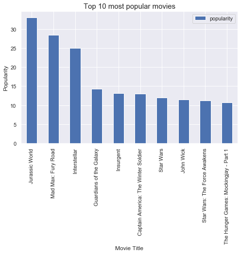

```python
# sorting the data in descending order according to the popularity and plotting a bar graph showing top 10 popular movies
sort_pop=df.sort_values(['popularity'],ascending=False)[:10][['original_title','popularity']]
sort_pop.set_index('original_title',inplace=True)
sort_pop.plot(kind ='bar',figsize=(8,5))

#setup the labels of the plot
plt.title('Top 10 most popular movies',fontsize=15);
plt.ylabel('Popularity',fontsize=12);
plt.xlabel('Movie Title',fontsize=12);
sns.set_style('darkgrid')
```

> Now, lets checkout the least popular ones.

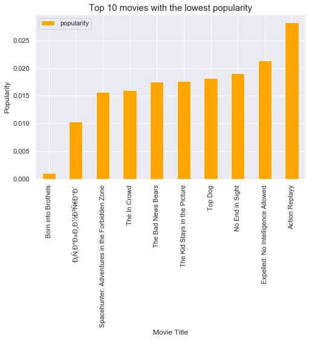

```python
# sorting the data in ascending order according to the popularity and plotting a bar graph showing top 10 least popular movies
least_pop=df.sort_values(['popularity'],ascending=True)[:10][['original_title','popularity']]
least_pop.set_index('original_title',inplace=True)
least_pop.plot(kind ='bar',figsize=(8,5),color='orange')

#setup the labels of the plot
plt.title('Top 10 movies with the lowest popularity',fontsize=15);
plt.ylabel('Popularity',fontsize=12);
plt.xlabel('Movie Title',fontsize=12);
sns.set_style('darkgrid')
```

#### It is observed that Jurassic World is the most popular movie whereas Born into Brothels is the least popular movie.

### Question 4. What is average runtime distribution of the movies?

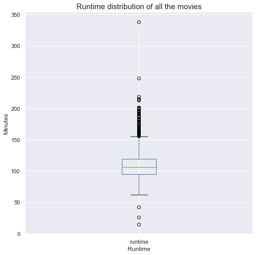

```python
# plotting runtime dstribution of movies on a box plot
df['runtime'].plot(kind = 'box', figsize = (8,8));
#setup the labels of the plot
plt.ylabel('Minutes', fontsize=12)
plt.xlabel('Runtime', fontsize=12)
plt.title('Runtime distribution of all the movies', fontsize=15);
```

#### The average runtime lies around 110 minutes and there are some outliers around 350 and 15 minutes.

### Question 5. On which year the movies released was the highest?

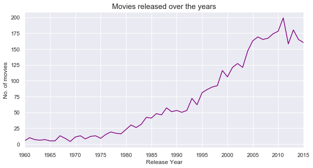

```python
# grouping the data by release year and counting the movies released in each year
year_release=df.groupby('release_year').count()['original_title']

# plotting the result using a line plot
year_release.plot(kind = 'line',xticks = np.arange(1960,2016,5),figsize = (10,5), color = 'purple')

#setup the labels of the plot
plt.xlabel('Release Year', fontsize=12)
plt.ylabel('No. of movies', fontsize=12)
plt.title('Movies released over the years', fontsize=15);
```

> Also finding out the figures.

```python
# finding out the year of most releases
year_release=df.groupby('release_year').count()['original_title']
year_release.sort_values(ascending=False).head(1)
```

```
release_year
2011    199
Name: original_title, dtype: int64
```

```python
# finding out the year of least releases
year_release=df.groupby('release_year').count()['original_title']
year_release.sort_values(ascending=False).tail(1)
```

```
release_year
1969    4
Name: original_title, dtype: int64
```

#### After observing the plot and the figures we can conclude that year 2011 year has the highest release of movies (199) and year 1969 has the least amount of releases (4). Also it is observed that the no. of movies released increased with the time.

### Question 5. Is release year of the movie associated with the profit?

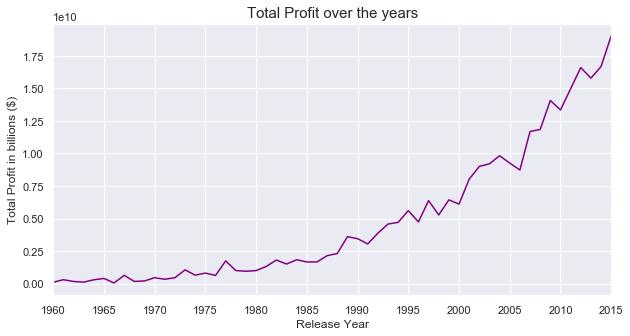

```python
# grouping the data by release year and summing the profit made in each year and plotting the graph b/w profit and release year
df.groupby('release_year')['profit'].sum().plot(kind='line',xticks = np.arange(1960,2016,5), figsize=(10,5), color='purple')

#setup the labels of the plot
plt.xlabel('Release Year', fontsize=12)
plt.ylabel('Total Profit in billions ($)', fontsize=12)
plt.title('Total Profit over the years', fontsize=15);
```

#### It is observed that with the increasing time, the total profit made in each year is also increasing.

### Question 6. Is the average runtime of movies consistent throughout the years?

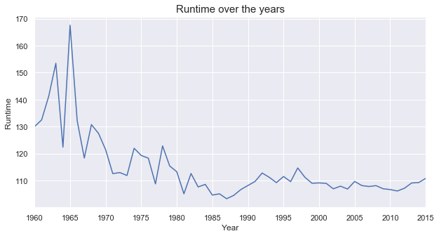

```python
# grouping the data by release year and calculating the mean of runtime of every made that year
avg_runtime=df.groupby('release_year').mean()['runtime']
avg_runtime.plot(kind = 'line',xticks = np.arange(1960,2016,5), figsize = (10,5), color = 'b');

#setup the labels of the plot
plt.title("Runtime over the years",fontsize=15);
plt.xlabel('Year',fontsize=12);
plt.ylabel('Runtime',fontsize=12);
```

#### It is observed that back in the days, the length of the movie used to much longer as compared to the latest movies.

### Question 7. How is popularity related to profit?

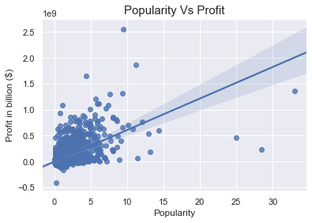

```python
ax = sns.regplot(x=df['popularity'],y=df['profit'],color='b')

#setup the labels of the plot
ax.set_title("Popularity Vs Profit",fontsize=15)
ax.set_xlabel("Popularity",fontsize=12)
ax.set_ylabel("Profit in billion ($)",fontsize=12)

sns.set(rc={'figure.figsize':(8,5)})
sns.set_style('whitegrid')
```

#### It is observed that profit is positively correlated with popularity which means that movie with high popularity tends to make higher profit.

### Question 8. How is budget related to profit?

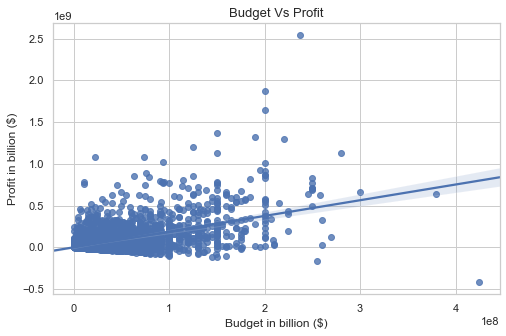

```python
ax = sns.regplot(x=df['budget'],y=df['profit'],color='b')

#setup the labels of the plot
ax.set_title("Budget Vs Profit",fontsize=13)
ax.set_xlabel("Budget in billion ($)",fontsize=12)
ax.set_ylabel("Profit in billion ($)",fontsize=12)

sns.set(rc={'figure.figsize':(8,5)})
sns.set_style('whitegrid')
```

#### It is observed that profit is positively correlated with budget which means that movie with more budget tends to make higher profit.

### Question 9. Which month has most movie releases?

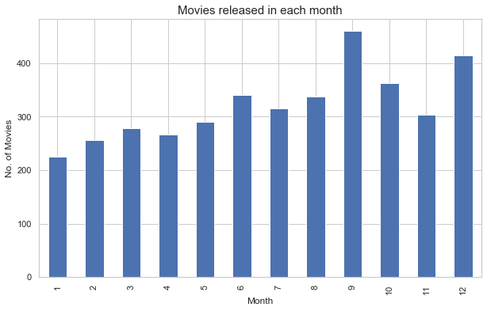

```python
#ploting a bar graph of movies released in each month
df['release_date'].dt.month.value_counts().sort_index().plot(kind='bar',figsize=(10,6))

#setup the labels of the plot
plt.title('Movies released in each month',fontsize=15);
plt.ylabel('No. of Movies',fontsize=12);
plt.xlabel('Month',fontsize=12);
sns.set_style('darkgrid')
```

#### It is shown that most no. of movies were released in September followed by December.

### Question 10. What is the correlation between each parameters?

```python
# Use corr to compute correlation of columns
df.corr()
```

|  | popularity | budget | revenue | runtime | vote_count | vote_average | release_year | profit |
| --- | --- | --- | --- | --- | --- | --- | --- | --- |
| popularity | 1.000000 | 0.446987 | 0.615535 | 0.215092 | 0.780096 | 0.317866 | 0.173278 | 0.596201 |
| budget | 0.446987 | 1.000000 | 0.688556 | 0.260977 | 0.556937 | 0.024169 | 0.268040 | 0.526818 |
| revenue | 0.615535 | 0.688556 | 1.000000 | 0.250298 | 0.754567 | 0.227123 | 0.139140 | 0.979133 |
| runtime | 0.215092 | 0.260977 | 0.250298 | 1.000000 | 0.273771 | 0.351712 | -0.112453 | 0.220238 |
| vote_count | 0.780096 | 0.556937 | 0.754567 | 0.273771 | 1.000000 | 0.387210 | 0.207191 | 0.728348 |
| vote_average | 0.317866 | 0.024169 | 0.227123 | 0.351712 | 0.387210 | 1.000000 | -0.134246 | 0.259435 |
| release_year | 0.173278 | 0.268040 | 0.139140 | -0.112453 | 0.207191 | -0.134246 | 1.000000 | 0.087971 |
| profit | 0.596201 | 0.526818 | 0.979133 | 0.220238 | 0.728348 | 0.259435 | 0.087971 | 1.000000 |

### Question 11. What are the most frequent genres, actor and director?

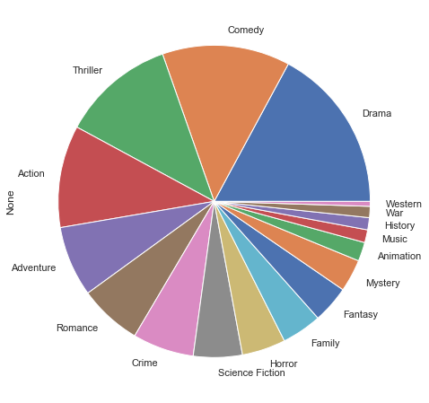

```python
#splitting the genre column to extract the data
genre_data=df['genres'].str.cat(sep='|')
genres = pd.Series(genre_data.split('|'))

#plotting a pie chart of genre which are most frequent
genres.value_counts(ascending=False).head(17).plot(kind='pie',figsize=(8,8));
```

#### As depicted, Drama is the most frequent genre followed by Comedy.

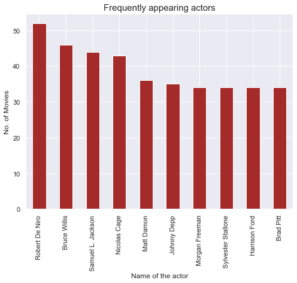

```python
#splitting the cast column to extract the data
cast_data=df['cast'].str.cat(sep='|')
casts = pd.Series(cast_data.split('|'))

#plotting a bar graph showing the most frquently hired actors
casts.value_counts(ascending=False).head(10).plot(kind='bar',figsize=(8,6),color='brown');
#setup the labels of the plot
plt.title('Frequently appearing actors',fontsize=15);
plt.ylabel('No. of Movies',fontsize=12);
plt.xlabel('Name of the actor',fontsize=12);
sns.set_style('darkgrid')
```

#### Robert De Niro is the topmost frequently appearing actor followed by Bruce Willis

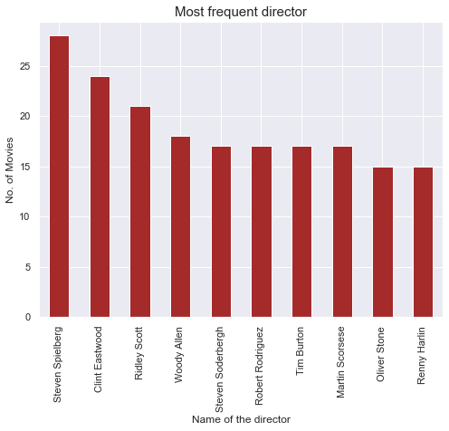

```python
#splitting the director column to extract the data
director_data=df['director'].str.cat(sep='|')
directors = pd.Series(director_data.split('|'))

#plotting a bar graph showing the most frquently hired actors
directors.value_counts(ascending=False).head(10).plot(kind='bar',figsize=(8,6),color='brown')

#setup the labels of the plot
plt.title('Most frequent director',fontsize=15);
plt.ylabel('No. of Movies',fontsize=12);
plt.xlabel('Name of the director',fontsize=12);
sns.set_style('darkgrid')
```

#### Steven Spielberg has directed most of the movies followed by Clint Eastwood.

### Question 12. Which is the most profitable genre, actor and director?

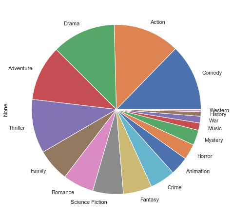

```python
#selecting the data which has made higher profit than the total average profit made.
top_profit=df[df['profit']>df['profit'].mean()][['profit','genres','cast','director','production_companies']]

#splitting the genre column to extract the data
genre_data=top_profit['genres'].str.cat(sep='|')
genres = pd.Series(genre_data.split('|'))

#plotting a pie chart of genre which are most profitable
genres.value_counts(ascending=False).head(17).plot(kind='pie',figsize=(8,8));
```

#### According to the results, Comedy is the most profitable genre followed by Action and the Drama.

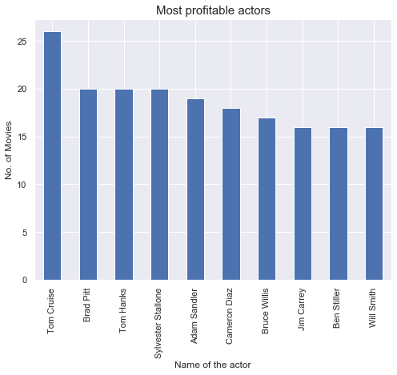

```python
#splitting the cast column to extract the data
cast_data=top_profit['cast'].str.cat(sep='|')
casts = pd.Series(cast_data.split('|'))

#plotting a bar graph showing the most profitable actors
casts.value_counts(ascending=False).head(10).plot(kind='bar',figsize=(8,6),color='b');
#setup the labels of the plot
plt.title('Most profitable actors',fontsize=15);
plt.ylabel('No. of Movies',fontsize=12);
plt.xlabel('Name of the actor',fontsize=12);
sns.set_style('darkgrid')
```

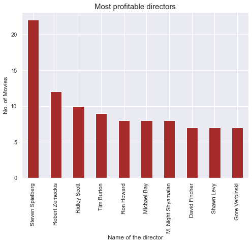

```python
#splitting the director column to extract the data
director_data=top_profit['director'].str.cat(sep='|')
directors = pd.Series(director_data.split('|'))

#plotting a bar graph showing the most profitable directors
directors.value_counts(ascending=False).head(10).plot(kind='bar',figsize=(8,6),color='brown')
#setup the labels of the plot
plt.title('Most profitable directors',fontsize=15);
plt.ylabel('No. of Movies',fontsize=12);
plt.xlabel('Name of the director',fontsize=12);
sns.set_style('darkgrid')
```

#### Steven Spielberg is the most profitable director of all of them followed by Robert Zemeckis and then Ridley Scotts.

### Question 13. What are most profitable production companies?

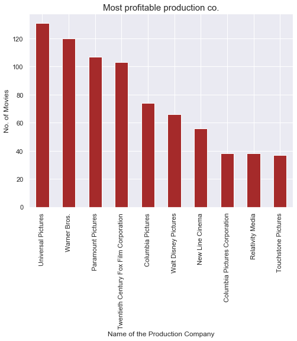

```python
#splitting the production companies column to extract the data
production_co_data=top_profit['production_companies'].str.cat(sep='|')
productions = pd.Series(production_co_data.split('|'))

#plotting a bar graph showing the most profitable production co.
productions.value_counts(ascending=False).head(10).plot(kind='bar',figsize=(8,6),color='brown')
#setup the labels of the plot
plt.title('Most profitable production co.',fontsize=15);
plt.ylabel('No. of Movies',fontsize=12);
plt.xlabel('Name of the Production Company',fontsize=12);
sns.set_style('darkgrid')
```

#### Universal Pictures is the most profitable production company of all of them followed by Warner Bros.

### Question 14. What are some parameters that are related to movies with high revenue?

```python
# Use corr to compute correlation of columns
df.corr()
```

|  | popularity | budget | revenue | runtime | vote_count | vote_average | release_year | profit |
| --- | --- | --- | --- | --- | --- | --- | --- | --- |
| popularity | 1.000000 | 0.446987 | 0.615535 | 0.215092 | 0.780096 | 0.317866 | 0.173278 | 0.596201 |
| budget | 0.446987 | 1.000000 | 0.688556 | 0.260977 | 0.556937 | 0.024169 | 0.268040 | 0.526818 |
| revenue | 0.615535 | 0.688556 | 1.000000 | 0.250298 | 0.754567 | 0.227123 | 0.139140 | 0.979133 |
| runtime | 0.215092 | 0.260977 | 0.250298 | 1.000000 | 0.273771 | 0.351712 | -0.112453 | 0.220238 |
| vote_count | 0.780096 | 0.556937 | 0.754567 | 0.273771 | 1.000000 | 0.387210 | 0.207191 | 0.728348 |
| vote_average | 0.317866 | 0.024169 | 0.227123 | 0.351712 | 0.387210 | 1.000000 | -0.134246 | 0.259435 |
| release_year | 0.173278 | 0.268040 | 0.139140 | -0.112453 | 0.207191 | -0.134246 | 1.000000 | 0.087971 |
| profit | 0.596201 | 0.526818 | 0.979133 | 0.220238 | 0.728348 | 0.259435 | 0.087971 | 1.000000 |

As vote count is not consistent for all the movies so it is not a good parameter determining the revenue.

## Limitations

Also, the budget and revenue columns did not specify currency so there may be some differences due to fluctuating exchange rates. Different countries may also have different rules and regulations they have to follow which may restrict them from artistiic freedom.

Rows with NaN values were dropped, hence a lot of important data might have been lost in the process.

There are a lot of crew members apart from the director, cast and the production companies who help in creating a movie like writers, screenplay writers, editors, etc. but there was no data to analyse those aspects.